# POLISCI 150B/355B Logistic regession tutorial

Go back to Index

In this tutorial we review the advantages of logistic regression over linear regression for binary outcomes, examine how to interpret logistic regression coefficients, and discuss decision boundaries in classification.

## Why use logistic regression?

There are several advantages of using logistic regression over linear regression when dealing with a binary outcome. That said, the “linear probability model” (LPM) – which is simply linear regression with a binary outcome – is still widely used in the social sciences (because the advantages of logistic regression are not always that large and LPM offers ease of interpretation).

As we discussed in class, the first advantage of logistic regression is that it ensures all predictions fall in the range (0,1). In LPM, there is nothing preventing the model from making predictions outside of this interval.

Second, in classification, LPM can sometimes exhibit undesirable sensitivity to new data. Let’s see this in action:

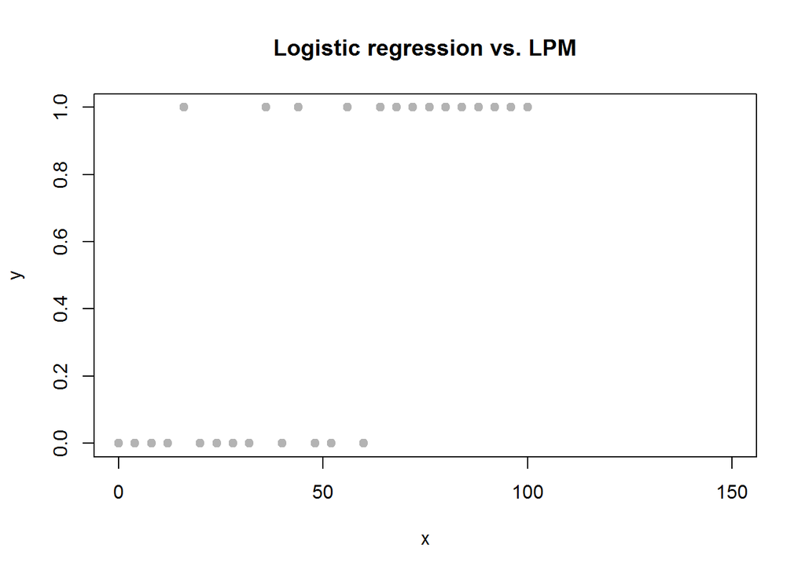

```r
### First let's simulate a dataset
# simulates a continuous x variable and binary y variable.
set.seed(35671)
n     <- 26
x     <- seq(0, 100, length=n)
probY <- 1 / (1 + exp(-1 * (-5 + 0.1 * x)))
y     <- rbinom(n, size=1, prob=probY)

# plots the data
plot(x, y, xlim=c(0, 150), col='gray70', pch=19, main='Logistic regression vs. LPM')
```

```r
# fits LPM and logistic regression.
lmResult1  <- lm(y ~ x)
glmResult1 <- glm(y ~ x, family='binomial')

summary(lmResult1)
```

```
##
## Call:
## lm(formula = y ~ x)
##
## Residuals:
##      Min       1Q   Median       3Q      Max
## -0.65470 -0.22462 -0.01521  0.19419  0.85675
##
## Coefficients:
##              Estimate Std. Error t value Pr(>|t|)
## (Intercept) -0.042735   0.141342  -0.302    0.765
## x            0.011624   0.002424   4.795 6.99e-05 ***
## ---
## Signif. codes:  0 '***' 0.001 '**' 0.01 '*' 0.05 '.' 0.1 ' ' 1
##
## Residual standard error: 0.3708 on 24 degrees of freedom
## Multiple R-squared:  0.4893, Adjusted R-squared:  0.468
## F-statistic:    23 on 1 and 24 DF,  p-value: 6.988e-05
```

```r
summary(glmResult1)
```

```
##
## Call:
## glm(formula = y ~ x, family = "binomial")
##
## Deviance Residuals:
##     Min       1Q   Median       3Q      Max
## -1.6503  -0.5754   0.1983   0.4944   2.1657
##
## Coefficients:
##             Estimate Std. Error z value Pr(>|z|)
## (Intercept) -3.44813    1.38710  -2.486  0.01292 *
## x            0.07523    0.02729   2.756  0.00585 **
## ---
## Signif. codes:  0 '***' 0.001 '**' 0.01 '*' 0.05 '.' 0.1 ' ' 1
##
## (Dispersion parameter for binomial family taken to be 1)
##
##     Null deviance: 35.890  on 25  degrees of freedom
## Residual deviance: 20.261  on 24  degrees of freedom
## AIC: 24.261
##
## Number of Fisher Scoring iterations: 5
```

Let’s compare the predictions of these two models graphically:

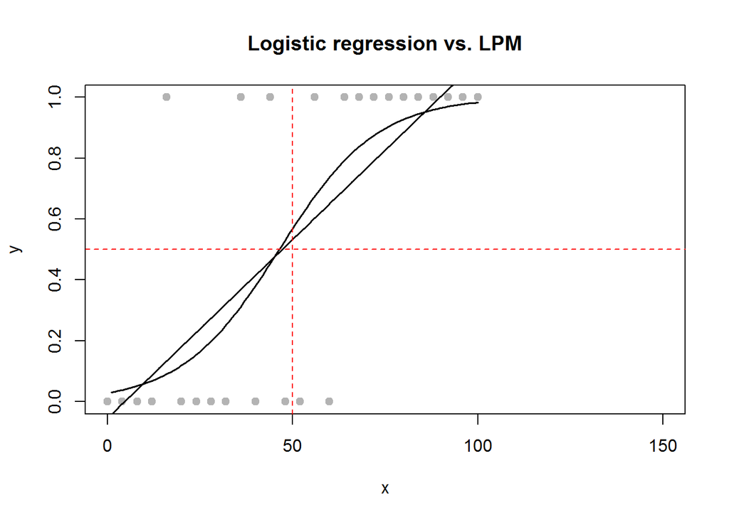

```r
# generates predicted values.
xSeq            <- data.frame(x=seq(0, 100, length=100))
glmPredictions1 <- predict(glmResult1, newdata=xSeq, type='response')
lmPredictions1  <- predict(lmResult1, newdata=xSeq)

# plots the predicted values
plot(x, y, xlim=c(0, 150), col='gray70', pch=19, main='Logistic regression vs. LPM')
lines(glmPredictions1, type='l', lwd=1.5)
lines(lmPredictions1, type='l', lwd=1.5)
abline(h=0.5, lty=2, col='red')
abline(v=mean(x), lty=2, col='red')
```

To fix ideas it is useful to repeat each step of the prediction with our costumized functions. Let’s start calculating $\hat y$. That is:

$$\hat y_i = \hat \beta_0 + \hat \beta_1 x_i$$
Where $\hat \beta_0$ and $\hat \beta_1$ come from the logistic regression.

*Note: For the LMP these coefficients minimize the sum of squared errors. For a logistic regression these coefficients are optmizied using a technique Maximum Likelihood Estimation. This method is not discussed here but is important to know that the process between LMP and logistic regression differs.*

```r
#### Prediction using inner product
my_predict_glm  <- as.numeric(glmResult1$coefficients %*% t(cbind(1,x)))
my_predict_glm
```

```
##  [1] -3.4481319 -3.1472130 -2.8462941 -2.5453752 -2.2444563 -1.9435374
##  [7] -1.6426185 -1.3416996 -1.0407808 -0.7398619 -0.4389430 -0.1380241
## [13]  0.1628948  0.4638137  0.7647326  1.0656515  1.3665704  1.6674892
## [19]  1.9684081  2.2693270  2.5702459  2.8711648  3.1720837  3.4730026
## [25]  3.7739215  4.0748404
```

```r
### We can retrieve the same values if inside the predict function we specify type='link'
#predict(glmResult1, type='link')
```

One thing to notice here is that these values are larger than one and smaller than minus one. That is because we still need to transform them into probabilities with the inverse logit function:

$$\hat p_i = \dfrac{1}{1 + exp^ {- \hat \beta_0 + \hat \beta_1 x_i}}$$

This is the same than:

$$\hat p_i = \dfrac{1} {1 + exp^ {-\hat y}}$$

Applying this function to each point gives:

```r
my_inv <- function(bx){
       result <- 1/(1+exp(-bx))
       return(result)
}
my_predict_glm2 <- my_inv(my_predict_glm )
my_predict_glm2
```

```
##  [1] 0.03082462 0.04120124 0.05487320 0.07273780 0.09582873 0.12525975
##  [7] 0.16210907 0.20723069 0.26099937 0.32303435 0.39199286 0.46554865
## [13] 0.54063389 0.61391850 0.68238034 0.74376907 0.79682548 0.84124078
## [19] 0.87744003 0.90630466 0.92892193 0.94640246 0.95977012 0.96990977
## [25] 0.97755357 0.98328907
```

Which are probability values. We can plot these and see that each value of x its going to be related with a probability.

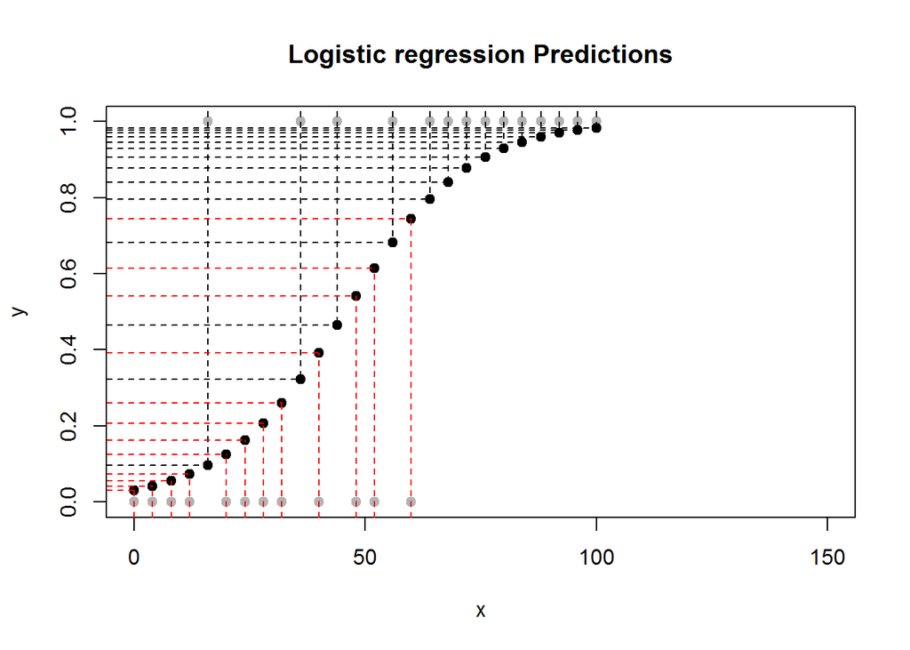

```r
#install.packages('plotrix')
library(plotrix)
plot(x, y, xlim=c(0, 150), col='gray70', pch=19, main='Logistic regression Predictions')
points(x, my_predict_glm2, col='black', pch=19)
for(i in 1:length(x)){
    if(y[i]==0){
        ablineclip(h=my_predict_glm2[i], lty=2 , x2=x[i], col='red' )
        ablineclip(v=x[i], lty=2 , y2=my_predict_glm2[i] , col='red')
    }
   if(y[i]==1){
        ablineclip(h=my_predict_glm2[i], lty=2 , x2=x[i] )
        ablineclip(v=x[i], lty=2 , y1=my_predict_glm2[i] )
    }
}
```

Now let’s see what happens when we collect a few additional data points, which just happen to be outliers on the x-axis.

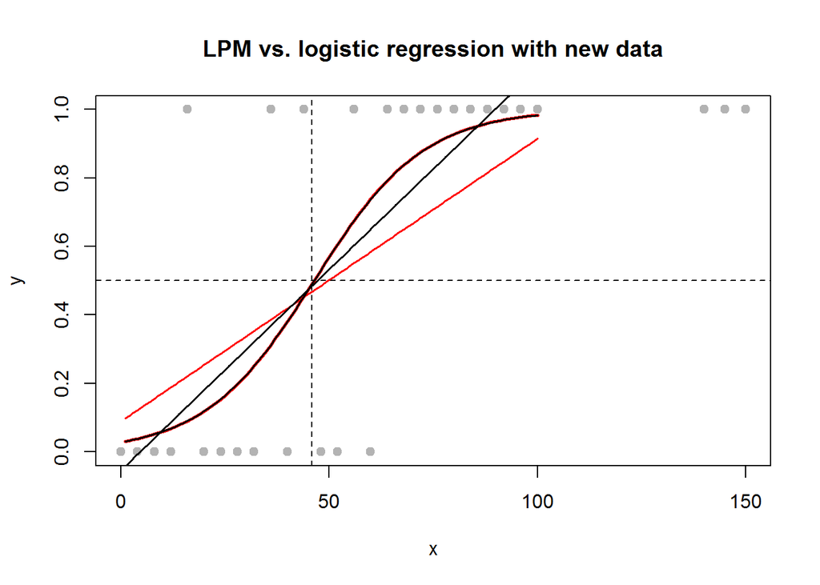

```r
# adds three new observations to the data
x <- c(x, 140, 145, 150)
y <- c(y, 1, 1, 1)

# plots the revised data.
plot(x, y, xlim=c(0, 150), col='gray70', pch=19, main='LPM vs. logistic regression with new data')

# fits LPM and logistic regression.
lmResult2 <- lm(y ~ x)
glmResult2 <- glm(y ~ x, family='binomial')

# generates predicted values.
xSeq <- data.frame(x=seq(0, 100, length=100))
glmPredictions2 <- predict(glmResult2, newdata=xSeq, type='response')
lmPredictions2 <- predict(lmResult2, newdata=xSeq)

# plots the predicted values for the new models and original models.
lines(glmPredictions2, type='l', lwd=2.5, col='red')
lines(lmPredictions2, type='l', lwd=1.5, col='red')
lines(glmPredictions1, type='l', lwd=1.5)
lines(lmPredictions1, type='l', lwd=1.5)
abline(h=0.5, lty=2)
abline(v=coef(glmResult1)[1]/(-1 * coef(glmResult1)[2]), lty=2)
```

The red lines represent the predicted values under the new data set (with the three additional observations). As we can see, the LPM regression line shifts, while the logistic regression line remains virtually unchanged (in fact, you can’t even see the red logistic regression line under the black one). This fits with our intuition: the discovery of some outliers on the x-axis which all fall in a single category should not change our belief about the decision boundary between making a prediction $\hat y = 0$ versus $\hat y = 1$.

Note: there are additional advantages of logistic regression over LPM – such as the fact that errors are heteroskedastic and not normally distributed in an LPM. However, these considerations are of less direct relevance to classification, so we will not be discussing them in detail here.

## Interpretting logistic regression coefficients

Once we’ve estimated a logistic regression model, how do we interpret the coefficients?

As a reminder, in the linear regression model

$$\hat y = \hat \beta_0 + \hat \beta_1 x_1 + \hat \beta_2 x_2$$

the marginal effect of a 1 unit increase in $x_1$ on our prediction of $\hat y$ is simply $\hat \beta_1$.

We can see this by comparing the equations for the predicted value of $y$ when we increase x by one unit:

$$\begin{aligned}
\hat y_1 &= \hat \beta_0 + \hat \beta_1 x_1 + \hat \beta_2 x_2 \\
\hat y_2 &= \hat \beta_0 + \hat \beta_1 (x_1 + 1) + \hat \beta_2 x_2 \\
\hat y_2 - \hat y_1 &= (\hat \beta_0 + \hat \beta_1 (x_1 + 1) + \hat \beta_2 x_2) - (\hat \beta_0 + \hat \beta_1 x_1 + \hat \beta_2 x_2) \\
\hat y_2 - \hat y_1 &= \hat \beta_1 (x_1 + 1) - \hat \beta_1 x_1 \\
\hat y_2 - \hat y_1 &= \hat \beta_1 x_1 + \hat \beta_1 - \hat \beta_1 x_1 \\
\hat y_2 - \hat y_1 &= \hat \beta_1
\end{aligned}$$

Now let’s think about the marginal effect of a one unit increase in $x_1$ in a logistic regression model such as:

$$log (\frac{\hat p(y)}{1 - \hat p(y)}) = \hat \beta_0 + \hat \beta_1 x_1 + \hat \beta_2 x_2$$

What is the marginal effect of $x_1$ in this model?

Using the same strategy we used for linear regression, we can simplify the marginal effect as follows:

$$\begin{aligned}
log (\frac{\hat p(y_1)}{1 - \hat p(y_1)}) &= \hat \beta_0 + \hat \beta_1 x_1 + \hat \beta_2 x_2 \\
log (\frac{\hat p(y_2)}{1 - \hat p(y_2)}) &= \hat \beta_0 + \hat \beta_1 (x_1 + 1) + \hat \beta_2 x_2 \\
log (\frac{\hat p(y_2)}{1 - \hat p(y_2)}) - log (\frac{\hat p(y_1)}{1 - \hat p(y_1)}) &= (\hat \beta_0 + \hat \beta_1 (x_1 + 1) + \hat \beta_2 x_2) - (\hat \beta_0 + \hat \beta_1 x_1 + \hat \beta_2 x_2) \\
log (\frac{\hat p(y_2)}{1 - \hat p(y_2)}) - log (\frac{\hat p(y_1)}{1 - \hat p(y_1)}) &= (\hat \beta_0 + \hat \beta_1 (x_1 + 1) + \hat \beta_2 x_2) - (\hat \beta_0 + \hat \beta_1 x_1 + \hat \beta_2 x_2) \\
log (\frac{\hat p(y_2)}{1 - \hat p(y_2)}) - log (\frac{\hat p(y_1)}{1 - \hat p(y_1)}) &= \hat \beta_1 (x_1 + 1) - \hat \beta_1 x_1 \\
log (\frac{\hat p(y_2)}{1 - \hat p(y_2)}) - log (\frac{\hat p(y_1)}{1 - \hat p(y_1)}) &= \hat \beta_1 x_1 + \hat \beta_1 - \hat \beta_1 x_1 \\
log (\frac{\hat p(y_2)}{1 - \hat p(y_2)}) - log (\frac{\hat p(y_1)}{1 - \hat p(y_1)}) &= \hat \beta_1
\end{aligned}$$

Next, by exponentiating both sides, we get

$$\begin{aligned}
exp(log (\frac{\hat p(y_2)}{1 - \hat p(y_2)}) - log (\frac{\hat p(y_1)}{1 - \hat p(y_1)})) &= exp(\hat \beta_1) \\
\frac{\hat p(y_2)}{1 - \hat p(y_2)} / \frac{\hat p(y_1)}{1 - \hat p(y_1)} &= exp(\hat \beta_1)
\end{aligned}$$

The complicated-looking term on the left-hand side is an odds ratio: the odds that an outcome ($y_2$ in this case) will occur under a certain set of conditions compared to the odds of the outcome occurring under another set of conditions ($y_1$ in this case).

$$\frac{\hat p(y_2)}{1 - \hat p(y_2)} / \frac{\hat p(y_1)}{1 - \hat p(y_1)} = \frac{odds(y_2)}{odds(y_1)} = exp(\hat \beta_1)$$

For instance, an odds ratio of 1.5 implies that the odds of $y_2$ being equal to 1 are 50% higher than the odds of $y_1$ being equal to 1.

In short, we can interpret $exp(\hat \beta_1)$ as a change in the odds ratio. For instance, if $\hat \beta_1 = 0.4$, then $exp(\hat \beta_1) = 1.49$, which implies that the odds ratio is multiplied by a factor of 1.49 (i.e. our estimate of the probability of $y = 1$ increases by 49% following a 1 unit increase in x).

Let’s see this in action using the `iraqVote` data:

```r
library(pscl)
str(iraqVote)
```

```
## 'data.frame':    100 obs. of  6 variables:
##  $ y         : num  1 1 1 1 1 1 1 1 0 1 ...
##  $ state.abb : Factor w/ 51 levels "AK","AL","AR",..: 2 2 1 1 4 4 3 3 5 5 ...
##  $ name      : Factor w/ 102 levels "AKAKA (D HI)",..: 87 88 75 94 63 71 53 68 11 41 ...
##  $ rep       : logi  TRUE TRUE TRUE TRUE TRUE TRUE ...
##  $ state.name: chr  "Alabama" "Alabama" "Alaska" "Alaska" ...
##  $ gorevote  : num  41.6 41.6 27.7 27.7 44.7 ...
```

```r
# fits a logistic regression of iraqVote on gorevote
iraqVoteGLM <- glm(y ~ gorevote, data=iraqVote, family='binomial')
summary(iraqVoteGLM)
```

```
##
## Call:
## glm(formula = y ~ gorevote, family = "binomial", data = iraqVote)
##
## Deviance Residuals:
##     Min       1Q   Median       3Q      Max
## -2.7102   0.1423   0.4355   0.6702   1.5393
##
## Coefficients:
##             Estimate Std. Error z value Pr(>|z|)
## (Intercept)  9.08218    2.16234   4.200 2.67e-05 ***
## gorevote    -0.16445    0.04319  -3.808  0.00014 ***
## ---
## Signif. codes:  0 '***' 0.001 '**' 0.01 '*' 0.05 '.' 0.1 ' ' 1
##
## (Dispersion parameter for binomial family taken to be 1)
##
##     Null deviance: 107.855  on 99  degrees of freedom
## Residual deviance:  86.793  on 98  degrees of freedom
## AIC: 90.793
##
## Number of Fisher Scoring iterations: 5
```

```r
# exponentiates the coefficient on gorevote
gorevoteCoef <- coef(iraqVoteGLM)[2]
exp(gorevoteCoef)
```

```
##  gorevote
## 0.8483562
```

```r
# to get the percent change, we simply substract 1 form the exponentiated coefficient
exp(gorevoteCoef) - 1
```

```
##   gorevote
## -0.1516438
```

So a 1 unit increase in `gorevote` is associated with about a 15% decrease in the probability of voting for the Iraq War (note that this is a 15% change, not a change in 15 percentage points).

Let’s see how this compares to the interpretation from an LPM:

```r
# fits an LPM of iraqVote on gorevote
iraqVoteLPM <- glm(y ~ gorevote, data=iraqVote, family='gaussian')
summary(iraqVoteLPM)
```

```
##
## Call:
## glm(formula = y ~ gorevote, family = "gaussian", data = iraqVote)
##
## Deviance Residuals:
##     Min       1Q   Median       3Q      Max
## -1.0214  -0.1397   0.1466   0.2632   0.5391
##
## Coefficients:
##              Estimate Std. Error t value Pr(>|t|)
## (Intercept)  1.703445   0.208222   8.181 1.04e-12 ***
## gorevote    -0.020637   0.004524  -4.562 1.47e-05 ***
## ---
## Signif. codes:  0 '***' 0.001 '**' 0.01 '*' 0.05 '.' 0.1 ' ' 1
##
## (Dispersion parameter for gaussian family taken to be 0.1490587)
##
##     Null deviance: 17.710  on 99  degrees of freedom
## Residual deviance: 14.608  on 98  degrees of freedom
## AIC: 97.426
##
## Number of Fisher Scoring iterations: 2
```

```r
# extracts the coefficient on gorevote.
coef(iraqVoteLPM)[2]
```

```
##    gorevote
## -0.02063737
```

So in the LPM, we estimate that a 1 unit increase in gorevote is associated with a 2 *percentage point* decrease in the probability of voting for the Iraq War.

# A problem of perfect separation

While running logistic regression models we can run into a problem called complete separation or quasi-complete separation. In this case, when we run a `glm` we get the following warning: `glm.fit: fitted probabilities numerically 0 or 1 occurred`. What does this mean?

As it’s name suggest complete separation happens when the outcome variable completely separates (or almost) a predictor or combination of predictors. Let’s take a look to this with simulated data:

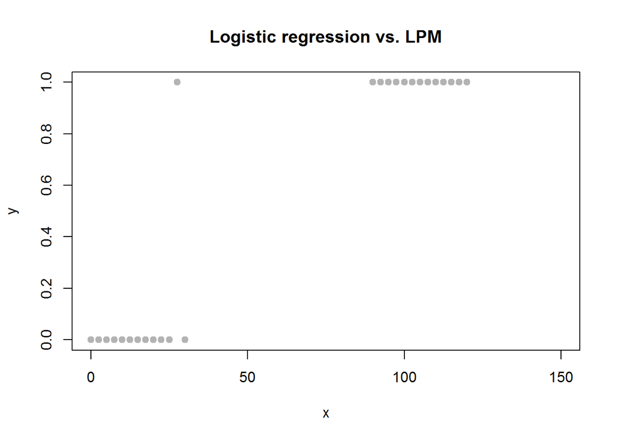

```r
### First let's simulate a dataset
# simulates a continuous x variable and binary y variable coercing separation
set.seed(9732)
n     <- 26
x     <- c(seq(0,30,length=n/2) , seq(90,120,length=n/2))
probY <- 1 / (1 + exp(-1 * (-5 + .15 * x)))
y     <- rbinom(n, size=1, prob=probY)

plot(x, y, xlim=c(0, 150), col='gray70', pch=19, main='Logistic regression vs. LPM')
```

In this case, we manipulated the data such as all observations with $y=0$ are below $x=30$ and all observations with $y=1$ are above $x=30$. In fact, due to the probability function only one observation is below $x=30$, so we find a problem of quasi-complete separation. As expected, wen we run the `glm` function we get the usual warning:

```r
# fits LPM and logistic regression.
glmResult1 <- glm(y ~ x, family='binomial')
```

```
## Warning: glm.fit: fitted probabilities numerically 0 or 1 occurred
```

```r
glmResult1
```

```
##
## Call:  glm(formula = y ~ x, family = "binomial")
##
## Coefficients:
## (Intercept)            x
##    -10.2317       0.3367
##
## Degrees of Freedom: 25 Total (i.e. Null);  24 Residual
## Null Deviance:       35.89
## Residual Deviance: 4.389     AIC: 8.389
```

```r
round(predict(glmResult1 , type="response"))
```

```
##  1  2  3  4  5  6  7  8  9 10 11 12 13 14 15 16 17 18 19 20 21 22 23 24 25
##  0  0  0  0  0  0  0  0  0  0  0  0  0  1  1  1  1  1  1  1  1  1  1  1  1
## 26
##  1
```

This is problematic at the separation limit because it forces the logistic curve to have a very weird shape:

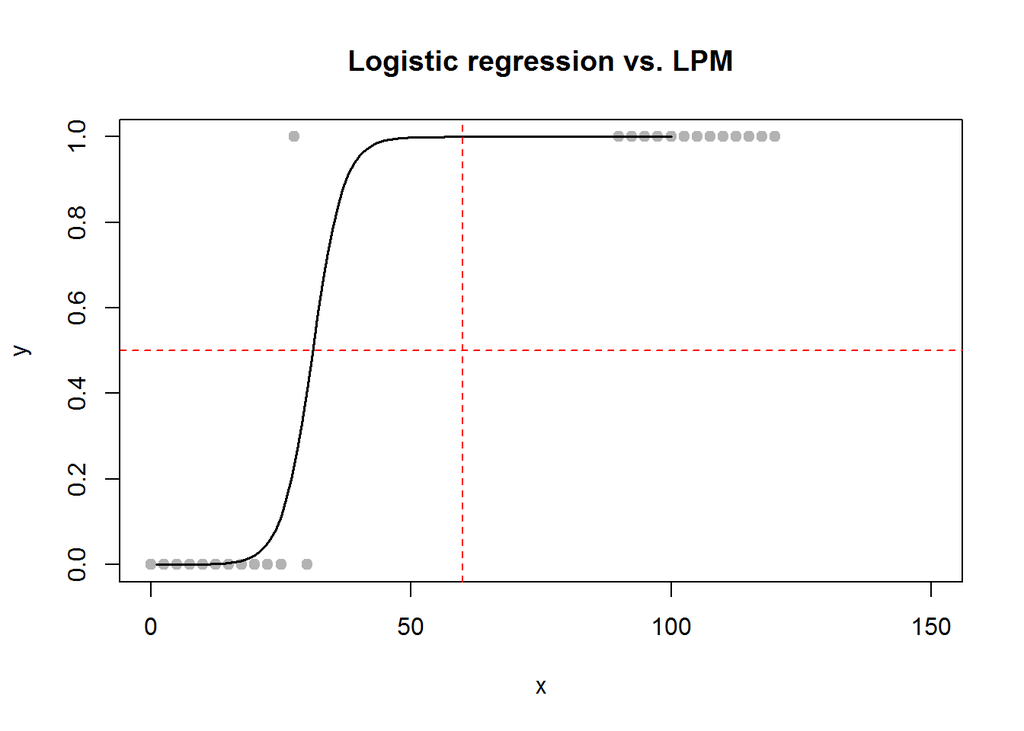

```r
### Plot
xSeq            <- data.frame(x=seq(0, 100, length=100))
glmPredictions1 <- predict(glmResult1, newdata=xSeq, type='response')
lmPredictions1  <- predict(lmResult1, newdata=xSeq)

# plots the predicted values
plot(x, y, xlim=c(0, 150), col='gray70', pch=19, main='Logistic regression vs. LPM')
lines(glmPredictions1, type='l', lwd=1.5)
abline(h=0.5, lty=2, col='red')
abline(v=mean(x), lty=2, col='red')
```

Even if the model will perfectly predict as $\hat p=0$ all observations with small $x$ and $\hat p=1$ all observations with large $x$, the value is indeterminate as $x$ approaches the separation. In other word,s it is not clear what would happen for all values that arein between since the slope of the logistic curve approaches to infinity in that region.

As the number of covariates increases this problem is more prevalent since the probability that a explanatory variable and the response are perfectly correlated increases. A simple solution to this problem is to implement a model that penalize the explanatory variables causing that problem (for example, LASSO).

**Much of this tutorial was written by Bobbie McDonald for POLISCI 150B (2016). I just added a couple of extra notes on perfect separation and more visual explanations.**